# Mouse PR degeneration literature

Statistical modeling using multinomial regression

Luca Della Santina, UCSF (Luca.DellaSantina@ucsf.edu)

Updated: 2020-10-26 15:13:29

# Summary

Multinomial regression analysis of PR degeneration literature compiled by JL. Purpose of the model is to understand which factors are important in determining a specific outcome (Stabilty vs Degeneration vs Compensation)

# Preamble

```r
require(car)
require(reshape2)
require(foreign)
require(nnet)
```

```r
require(ggplot2)
library(tidyverse)
require(ztable)
```

# Load and format data

Load the formatted data table provided by JL

```r
library(readr)
df <- read_csv("./PhotoreceptorLiterature_20201015.csv",
    col_types = cols(Outcome = col_factor(levels = c("Stability",
        "Degeneration", "Compensation")),
        Method = col_factor(levels = c("Str","Fun")),
        Perturbation = col_factor(levels = c("Dev","Mat")),
        RodCone = col_factor(levels = c("Rod","Cone", "RodCone")),
        Rod_YN = col_factor(levels = c("NotRod","Rod")),
        Cone_YN = col_factor(levels = c("NotCone","Cone")),
        Phototransduction_YN = col_factor(levels = c("NotPT","Phototransduction")),
        Signaling_YN = col_factor(levels = c("NotSig","Signaling")),
        Trafficking_YN = col_factor(levels = c("NotTff","Trafficking")),
        Metabolism_YN = col_factor(levels = c("Notmet","Meta")),
        ImmuneDNA_YN = col_factor(levels = c("NotImmune","Immune")),
        TF_YN = col_factor(levels = c("NotTF","TF")),
        ManipulationFull = col_factor(levels = c("Phototransduction","Signaling", "Trafficking", "Meta","Immune", "TF")),
        Manipulation = col_factor(levels = c("Phototransduction", "Signaling", "Trafficking", "Others"))))
#View(df)
```

# Frequency tables

Contingency tables for each factor, expressed first as absolute count then as percent frequency for each factor’s level

```r
writeLines("Method of investigation (Str= Structure, Fun=Function)\n\nFrequency count:")
```

```
## Method of investigation (Str= Structure, Fun=Function)
##
## Frequency count:
```

```r
ftable(df$Method, df$Outcome)
```

```
##      Stability Degeneration Compensation
##
## Str         83           81           58
## Fun         53          171           20
```

```r
writeLines("\nRelative Frequency %:")
```

```
##
## Relative Frequency %:
```

```r
prop.table(ftable(df$Method, df$Outcome))
```

```
##       Stability Degeneration Compensation
##
## Str  0.17811159   0.17381974   0.12446352
## Fun  0.11373391   0.36695279   0.04291845
```

```r
writeLines("\nType of perturbation (Dev=Developmental, Mature)\n\nFrequency count:")
```

```
##
## Type of perturbation (Dev=Developmental, Mature)
##
## Frequency count:
```

```r
ftable(df$Perturbation, df$Outcome)
```

```
##      Stability Degeneration Compensation
##
## Dev        115          234           53
## Mat         21           18           25
```

```r
writeLines("\nRelative Frequency %:")
```

```
##
## Relative Frequency %:
```

```r
prop.table(ftable(df$Perturbation, df$Outcome))
```

```
##       Stability Degeneration Compensation
##
## Dev  0.24678112   0.50214592   0.11373391
## Mat  0.04506438   0.03862661   0.05364807
```

```r
writeLines("\nType of photoreceptor affected (Rod, Cone, Rod+Cone)\n\nFrequency count:")
```

```
##
## Type of photoreceptor affected (Rod, Cone, Rod+Cone)
##
## Frequency count:
```

```r
ftable(df$RodCone, df$Outcome)
```

```
##          Stability Degeneration Compensation
##
## Rod             91          161           18
## Cone             6            9           16
## RodCone         39           82           44
```

```r
writeLines("\nRelative Frequency %:")
```

```
##
## Relative Frequency %:
```

```r
prop.table(ftable(df$RodCone, df$Outcome))
```

```
##           Stability Degeneration Compensation
##
## Rod      0.19527897   0.34549356   0.03862661
## Cone     0.01287554   0.01931330   0.03433476
## RodCone  0.08369099   0.17596567   0.09442060
```

```r
writeLines("\nType of Manipulation\n\nFrequency count:")
```

```
##
## Type of Manipulation
##
## Frequency count:
```

```r
ftable(df$Manipulation, df$Outcome)
```

```
##                    Stability Degeneration Compensation
##
## Phototransduction         51           98           30
## Signaling                 34           55           34
## Trafficking               38           67            6
## Others                    13           32            8
```

```r
writeLines("\nRelative Frequency %:")
```

```
##
## Relative Frequency %:
```

```r
prop.table(ftable(df$Manipulation, df$Outcome))
```

```
##                     Stability Degeneration Compensation
##
## Phototransduction  0.10944206   0.21030043   0.06437768
## Signaling          0.07296137   0.11802575   0.07296137
## Trafficking        0.08154506   0.14377682   0.01287554
## Others             0.02789700   0.06866953   0.01716738
```

# Exploratory Plotting

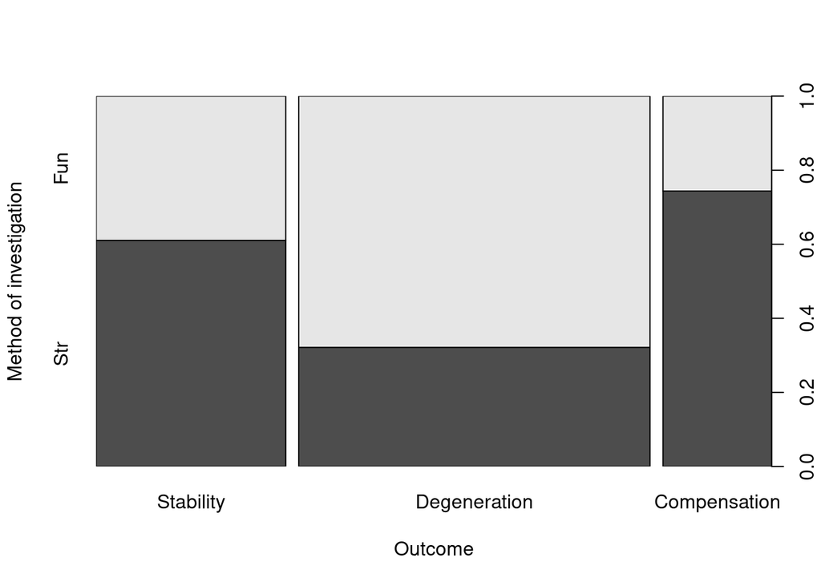

```r
#par(mfrow = c(3, 5), mar=c(2,2,2,2))

# Categorical
plot(df$Outcome, df$Method, xlab = "Outcome", ylab = "Method of investigation")
```

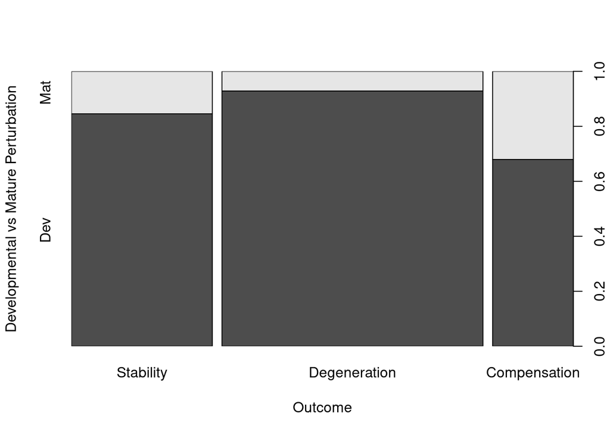

```r
plot(df$Outcome, df$Perturbation, xlab = "Outcome", ylab = "Developmental vs Mature Perturbation")
```

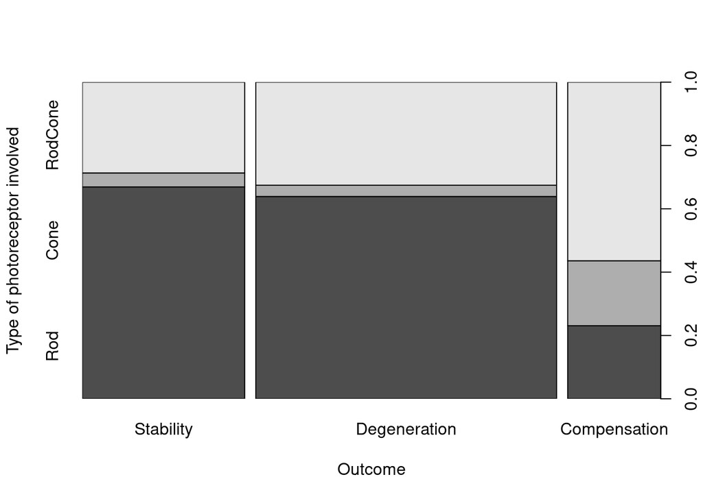

```r
plot(df$Outcome, df$RodCone, xlab = "Outcome", ylab = "Type of photoreceptor involved")
```

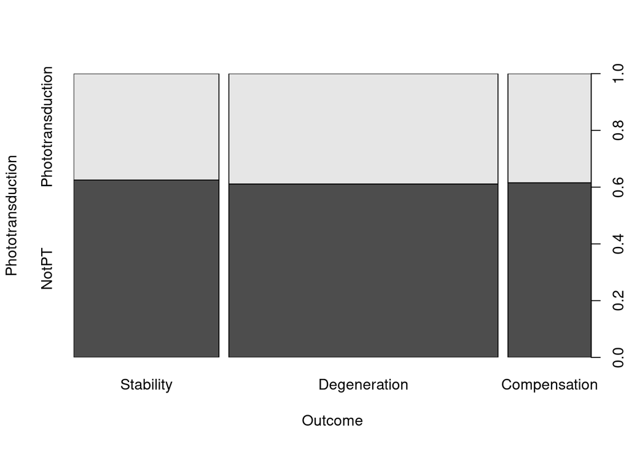

```r
plot(df$Outcome, df$Phototransduction_YN, xlab = "Outcome", ylab = "Phototransduction")
```

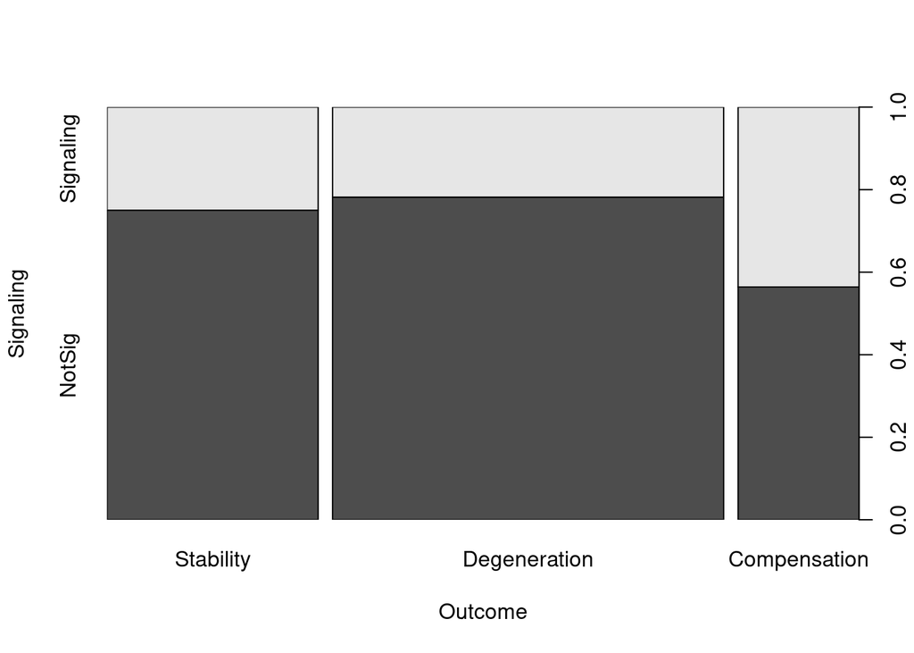

```r
plot(df$Outcome, df$Signaling_YN, xlab = "Outcome", ylab = "Signaling")
```

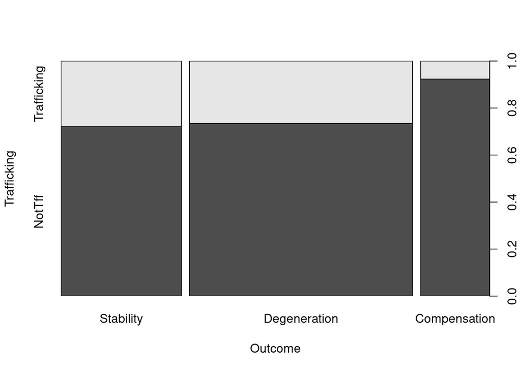

```r
plot(df$Outcome, df$Trafficking_YN, xlab = "Outcome", ylab = "Trafficking")
```

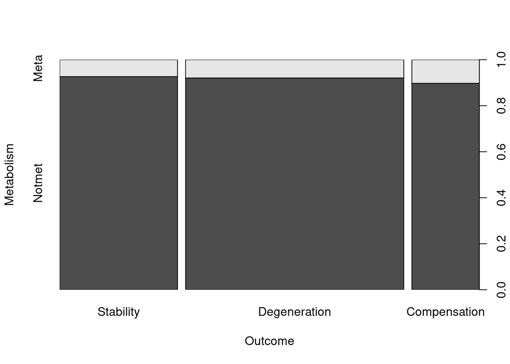

```r
plot(df$Outcome, df$Metabolism_YN, xlab = "Outcome", ylab = "Metabolism")
```

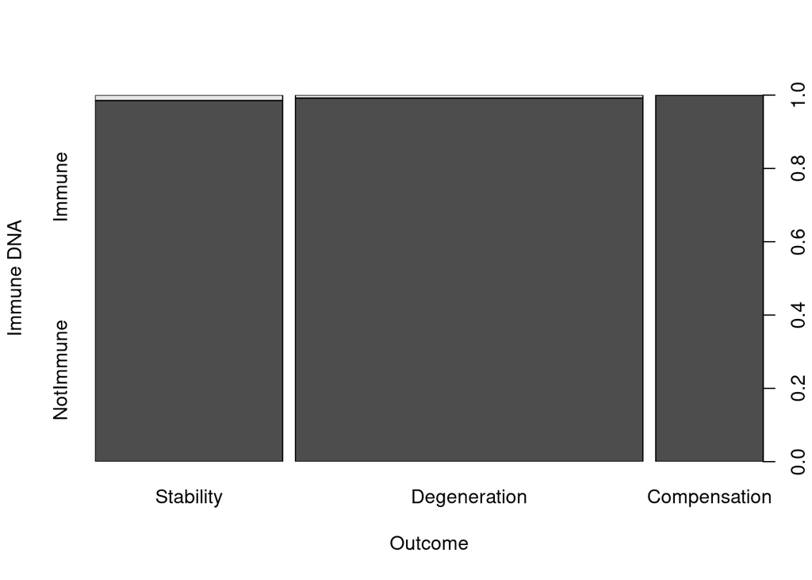

```r
plot(df$Outcome, df$ImmuneDNA_YN, xlab = "Outcome", ylab = "Immune DNA")
```

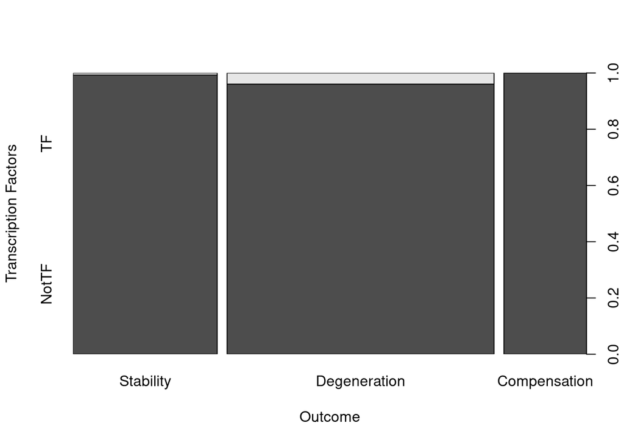

```r
plot(df$Outcome, df$TF_YN, xlab = "Outcome", ylab = "Transcription Factors")
```

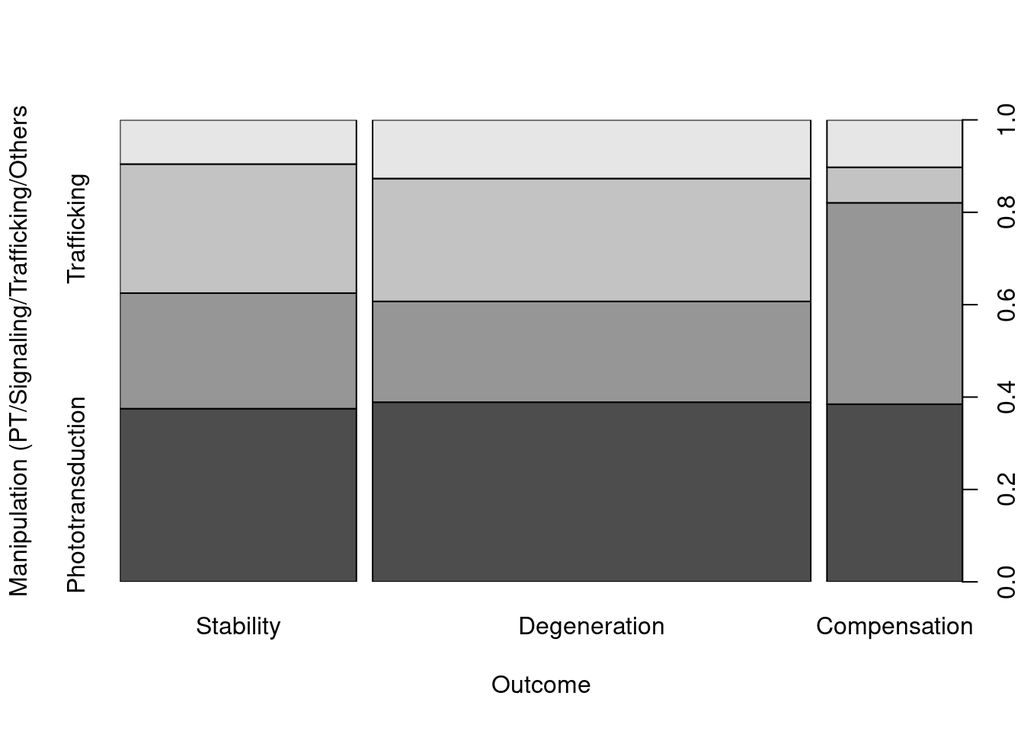

```r
plot(df$Outcome, df$Manipulation, xlab = "Outcome", ylab = "Manipulation (PT/Signaling/Trafficking/Others")
```

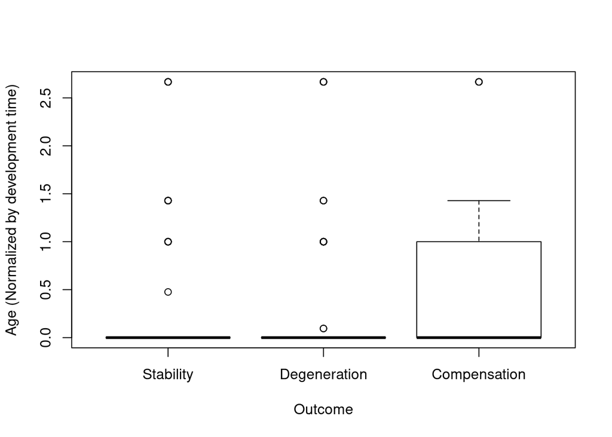

```r
# Numerical
plot(df$Outcome, df$NormalizedAge, xlab = "Outcome", ylab = "Age (Normalized by development time)")
```

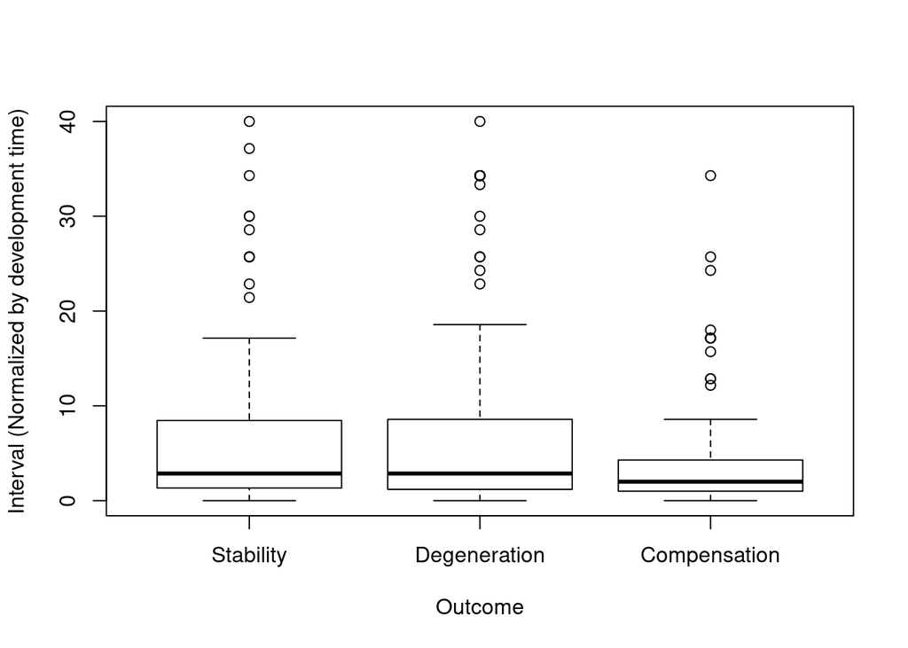

```r
plot(df$Outcome, df$NormalizedInterval, xlab = "Outcome", ylab = "Interval (Normalized by development time)")
```

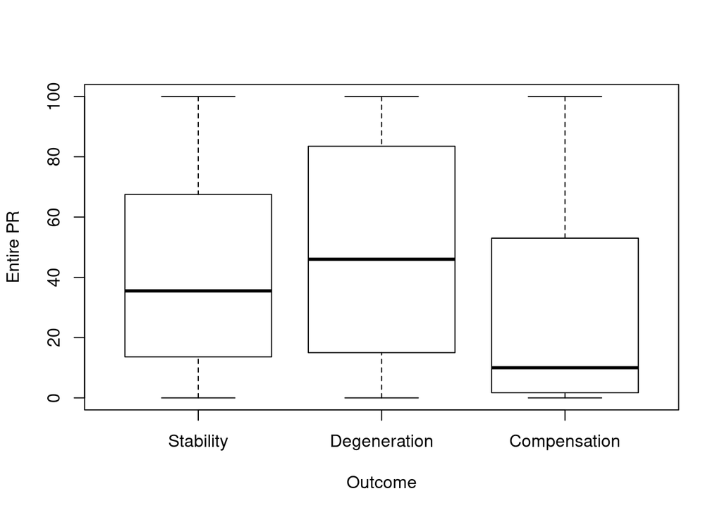

```r
plot(df$Outcome, df$EntirePR, xlab = "Outcome", ylab = "Entire PR")
```

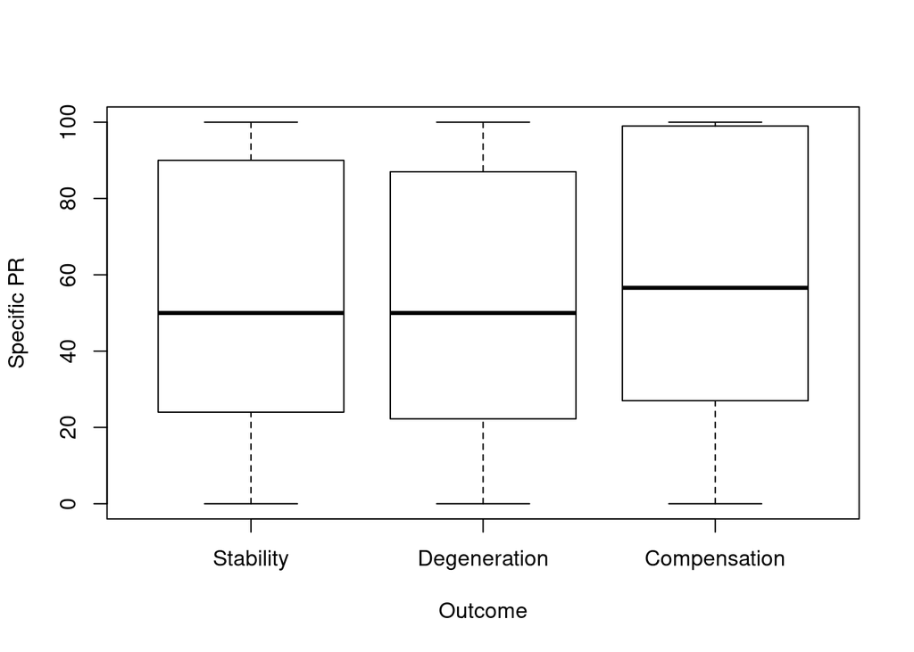

```r
plot(df$Outcome, df$SpecificPR, xlab = "Outcome", ylab = "Specific PR")
```

# Model 1: All parameters

## Multinomial Regression Model

Multinomial regression (nnet:multinom), it is a log-linear model for which the resulting coefficients reflect the ratio of probability

```r
df$Outcome<-relevel(df$Outcome, ref="Stability")

mdl <- multinom(Outcome ~ Method + RodCone +  Manipulation + NormalizedAge + NormalizedInterval + EntirePR + SpecificPR, data = df)
summary(mdl)
```

```
## Call:
## multinom(formula = Outcome ~ Method + RodCone + Manipulation +
##     NormalizedAge + NormalizedInterval + EntirePR + SpecificPR,
##     data = df)
##
## Coefficients:
##              (Intercept)  MethodFun RodConeCone RodConeRodCone
## Degeneration  -0.6202921  1.4973021   0.5592295       1.003582
## Compensation  -1.1950556 -0.2251307   2.3268756       1.813941
##              ManipulationSignaling ManipulationTrafficking ManipulationOthers
## Degeneration             0.3561405               0.1236339          0.2169821
## Compensation             0.4713776              -0.1105074          0.5779745
##              NormalizedAge NormalizedInterval     EntirePR   SpecificPR
## Degeneration    -0.5247106        -0.02369425  0.011358580 -0.006118580
## Compensation    -0.5845146        -0.03146243 -0.009132197  0.002617821
##
## Std. Errors:
##              (Intercept) MethodFun RodConeCone RodConeRodCone
## Degeneration   0.3239894 0.2517121   0.6279635      0.3332210
## Compensation   0.4460018 0.3616701   0.6322308      0.4546537
##              ManipulationSignaling ManipulationTrafficking ManipulationOthers
## Degeneration             0.3651679               0.3123080          0.3978058
## Compensation             0.4647073               0.5662831          0.5518410
##              NormalizedAge NormalizedInterval    EntirePR  SpecificPR
## Degeneration     0.2965998         0.01489253 0.006846985 0.007105981
## Compensation     0.3367124         0.02345179 0.007414174 0.007629149
##
## Residual Deviance: 793.5089
## AIC: 837.5089
```

## ANOVA

Parameters significant for the model are: Method of investigation, Rod/Cone affected, and Entire PR affected.

```r
Anova(mdl)
```

|  | LR Chisq | Df | Pr(>Chisq) |
| --- | --- | --- | --- |
| Method | 52.417172 | 2 | 4.147206e-12 |
| RodCone | 26.295766 | 4 | 2.758281e-05 |
| Manipulation | 2.494940 | 6 | 8.690336e-01 |
| NormalizedAge | 4.276679 | 2 | 1.178504e-01 |
| NormalizedInterval | 3.139795 | 2 | 2.080665e-01 |
| EntirePR | 8.604713 | 2 | 1.353662e-02 |
| SpecificPR | 1.579506 | 2 | 4.539570e-01 |

# Model 2: Method + RodCone

## Multinomial Regression Model

Multinomial regression (nnet:multinom), it is a log-linear model for which the resulting coefficients reflect the ratio of probability Removed the Manipulation parameter because not significant in the model

```r
df$Outcome<-relevel(df$Outcome, ref="Stability")

mdl <- multinom(Outcome ~ Method + RodCone + NormalizedAge + NormalizedInterval + EntirePR + SpecificPR, data = df)
summary(mdl)
```

```
## Call:
## multinom(formula = Outcome ~ Method + RodCone + NormalizedAge +
##     NormalizedInterval + EntirePR + SpecificPR, data = df)
##
## Coefficients:
##              (Intercept)  MethodFun RodConeCone RodConeRodCone NormalizedAge
## Degeneration   -0.503836  1.5047407   0.5030667      0.9829398    -0.4154610
## Compensation   -1.095594 -0.1822269   2.3355408      1.8971692    -0.4506403
##              NormalizedInterval    EntirePR   SpecificPR
## Degeneration        -0.02116886  0.01001656 -0.005064004
## Compensation        -0.02681398 -0.01085796  0.003477311
##
## Std. Errors:
##              (Intercept) MethodFun RodConeCone RodConeRodCone NormalizedAge
## Degeneration   0.2887479 0.2508970   0.6135689      0.3076321     0.2695833
## Compensation   0.3829900 0.3581008   0.5980877      0.4141692     0.3093180
##              NormalizedInterval    EntirePR  SpecificPR
## Degeneration         0.01436202 0.006649336 0.006972235
## Compensation         0.02263825 0.007148683 0.007445230
##
## Residual Deviance: 796.0039
## AIC: 828.0039
```

## ANOVA

Parameters significant for the model are: Method of investigation, Rod/Cone affected, and Entire PR affected.

```r
Anova(mdl)
```

|  | LR Chisq | Df | Pr(>Chisq) |
| --- | --- | --- | --- |
| Method | 52.373393 | 2 | 4.238989e-12 |
| RodCone | 32.833024 | 4 | 1.292292e-06 |
| NormalizedAge | 3.126496 | 2 | 2.094547e-01 |
| NormalizedInterval | 2.603145 | 2 | 2.721036e-01 |
| EntirePR | 9.390510 | 2 | 9.138538e-03 |
| SpecificPR | 1.482474 | 2 | 4.765241e-01 |

## Wald-test (2-tailed z test)

```r
z <- summary(mdl)$coefficients/summary(mdl)$standard.errors
p <- (1 - pnorm(abs(z), 0, 1)) * 2
p
```

```
##              (Intercept)    MethodFun  RodConeCone RodConeRodCone NormalizedAge
## Degeneration 0.081002456 2.004464e-09 4.122716e-01   1.397440e-03     0.1232868
## Compensation 0.004227951 6.108430e-01 9.422002e-05   4.635058e-06     0.1451486
##              NormalizedInterval  EntirePR SpecificPR
## Degeneration          0.1404958 0.1319646  0.4676488
## Compensation          0.2362332 0.1287939  0.6404625
```

## Relative risk

```r
writeLines("Ratio of the probability of choosing one outcome category over the reference category.\nOften referred as relative risk (and sometimes referred to as odds).\nCalculated by extracting the coefficients from the model and exponentiating\n")
```

```
## Ratio of the probability of choosing one outcome category over the reference category.
## Often referred as relative risk (and sometimes referred to as odds).
## Calculated by extracting the coefficients from the model and exponentiating
```

```r
exp(coef(mdl))
```

```
##              (Intercept) MethodFun RodConeCone RodConeRodCone NormalizedAge
## Degeneration   0.6042085 4.5029857    1.653785       2.672301     0.6600359
## Compensation   0.3343409 0.8334122   10.335048       6.666995     0.6372200
##              NormalizedInterval  EntirePR SpecificPR
## Degeneration          0.9790536 1.0100669  0.9949488
## Compensation          0.9735423 0.9892008  1.0034834
```

```r
#writeLines("\nPredicted probabilities for the source data (head of table)")
#head(fitted(mdl))
```

## Predicted probabilities

### Categorical Parameters

```r
dsimStr <- data.frame(Method = "Str",
                   RodCone = levels(df$RodCone),
                   NormalizedAge = mean(df$NormalizedAge),
                   NormalizedInterval = mean(df$NormalizedInterval),
                   EntirePR = mean(df$EntirePR),
                   SpecificPR = mean(df$SpecificPR))
predStr <- predict(mdl, newdata = dsimStr, "probs")

dsimFun <- data.frame(Method = "Fun",
                   RodCone = levels(df$RodCone),
                   NormalizedAge = mean(df$NormalizedAge),
                   NormalizedInterval = mean(df$NormalizedInterval),
                   EntirePR = mean(df$EntirePR),
                   SpecificPR = mean(df$SpecificPR))
predFun <- predict(mdl, newdata = dsimFun, "probs")

predStrFun <- rbind(predStr, predFun)
rgroup=c("Structure","Function")
n.rgroup=c(3,3)
dfPred <- as.data.frame(predStrFun)
row.names(dfPred) <- NULL
dfPred <- roundDf(dfPred, digits=2)
Photoreceptor <- c(levels(df$RodCone),levels(df$RodCone))
dfPred <- cbind(Photoreceptor, dfPred)
z <- ztable(dfPred) %>%
  addrgroup(rgroup=rgroup,n.rgroup=n.rgroup,cspan.rgroup=1) %>%
  print(caption = "Predicted outcome probability by method and photoreceptor type")
```

Predicted outcome probability by method and photoreceptor type

|  | Photoreceptor | Stability | Degeneration | Compensation |
| --- | --- | --- | --- | --- |
| Structure |  |  |  |  |
| 1 | Rod | 0.56 | 0.33 | 0.11 |
| 2 | Cone | 0.25 | 0.24 | 0.51 |
| 3 | RodCone | 0.26 | 0.40 | 0.34 |
| Function |  |  |  |  |
| 4 | Rod | 0.27 | 0.69 | 0.04 |
| 5 | Cone | 0.14 | 0.62 | 0.24 |
| 6 | RodCone | 0.11 | 0.77 | 0.12 |

### Age

Predicts outcome based on age (normalized by developmental time) at which the pathology starts

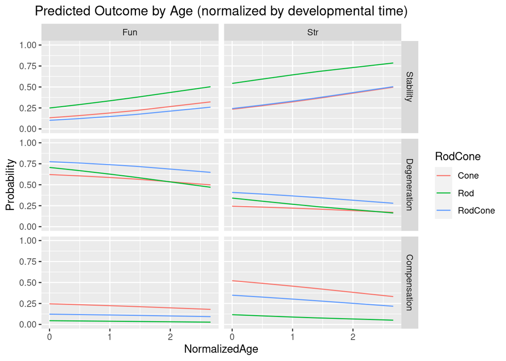

```r
dNormalizedAge <- data.frame(Method = rep(levels(df$Method), each = length(unique(df$NormalizedAge))*length(levels(df$RodCone))),
                   RodCone = rep(levels(df$RodCone), each = length(unique(df$NormalizedAge))),
                   NormalizedAge = rep(sort(unique(df$NormalizedAge)), length(levels(df$RodCone))),
                   NormalizedInterval = mean(df$NormalizedInterval),
                   EntirePR = mean(df$EntirePR),
                   SpecificPR = mean(df$SpecificPR))

# Store the predicted probabilities for each value of RodCone and NormalizedAge and append as last 3 columns to data frame (last three columns)
pred <- predict(mdl, newdata = dNormalizedAge, type = "probs", se = TRUE)
pp <- cbind(dNormalizedAge, pred)

# calculate the mean probabilities within each level of RodCone
#by(pp[, (ncol(pp)-2):ncol(pp)], pp$RodCone, colMeans)

# Collapse the data frame by outcome
lpp <- melt(pp, id.vars = c("RodCone", "NormalizedAge", "Method"), measure.vars = levels(df$Outcome), value.name = "Probability")

# Plot predicted probabilities across NormalizedAge values for each level of RodCone facetted by Outcome and Method of Investigation
ggplot(lpp, aes(x = NormalizedAge, y = Probability, colour = RodCone)) +
  geom_line() + facet_grid(variable ~ Method, scales = "free_x") +
  ggtitle("Predicted Outcome by Age (normalized by developmental time)") +
  theme(plot.title = element_text(hjust = 0.5)) + ylim(0,1)
```

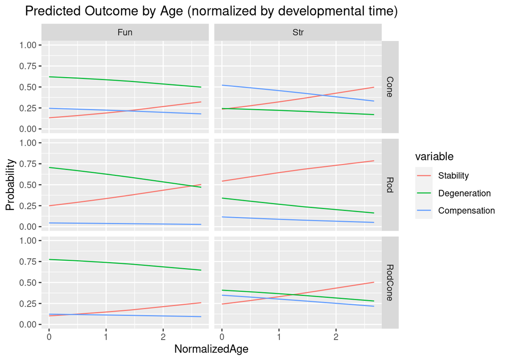

```r
# Plot predicted probabilities across NormalizedAge values for each level of Outcome facetted by RodCone and Method of Investigation
ggplot(lpp, aes(x = NormalizedAge, y = Probability, colour = variable)) +
  geom_line() + facet_grid(RodCone ~ Method, scales = "free_x") +
  ggtitle("Predicted Outcome by Age (normalized by developmental time)") +
  theme(plot.title = element_text(hjust = 0.5)) + ylim(0,1)
```

### Interval

Predicts outcome based on time interval (normalized by developmental time) during which the pathology develops

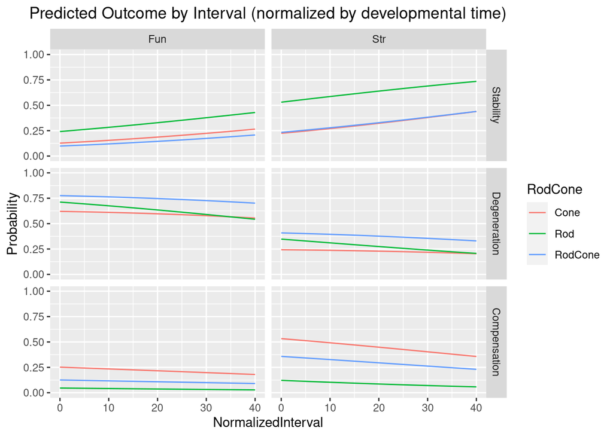

```r
dNormalizedInterval <- data.frame(Method = rep(levels(df$Method), each = length(unique(df$NormalizedInterval))*length(levels(df$RodCone))),
                   RodCone = rep(levels(df$RodCone), each = length(unique(df$NormalizedInterval))),
                   NormalizedAge =  mean(df$NormalizedAge),
                   NormalizedInterval = rep(sort(unique(df$NormalizedInterval)), length(levels(df$RodCone))),
                   EntirePR = mean(df$EntirePR),
                   SpecificPR = mean(df$SpecificPR))

# Store the predicted probabilities for each value of RodCone and D50 and append as last 3 columns to dataframe (columns 9, 10, 11)
pp <- cbind(dNormalizedInterval, predict(mdl, newdata = dNormalizedInterval, type = "probs", se = TRUE))

# calculate the mean probabilities within each level of RodCone
#by(pp[, (ncol(pp)-2):ncol(pp)], pp$RodCone, colMeans)

# Collapse the data frame by outcome
lpp <- melt(pp, id.vars = c("RodCone", "NormalizedInterval", "Method"), measure.vars = levels(df$Outcome), value.name = "Probability")

# Plot predicted probabilities across NormalizedInterval values for each level of RodCone facetted by Outcome and Method of investigation
ggplot(lpp, aes(x = NormalizedInterval, y = Probability, colour = RodCone)) +
  geom_line() + facet_grid(variable ~ Method, scales = "free_x") +
  ggtitle("Predicted Outcome by Interval (normalized by developmental time)") +
  theme(plot.title = element_text(hjust = 0.5)) + ylim(0,1)
```

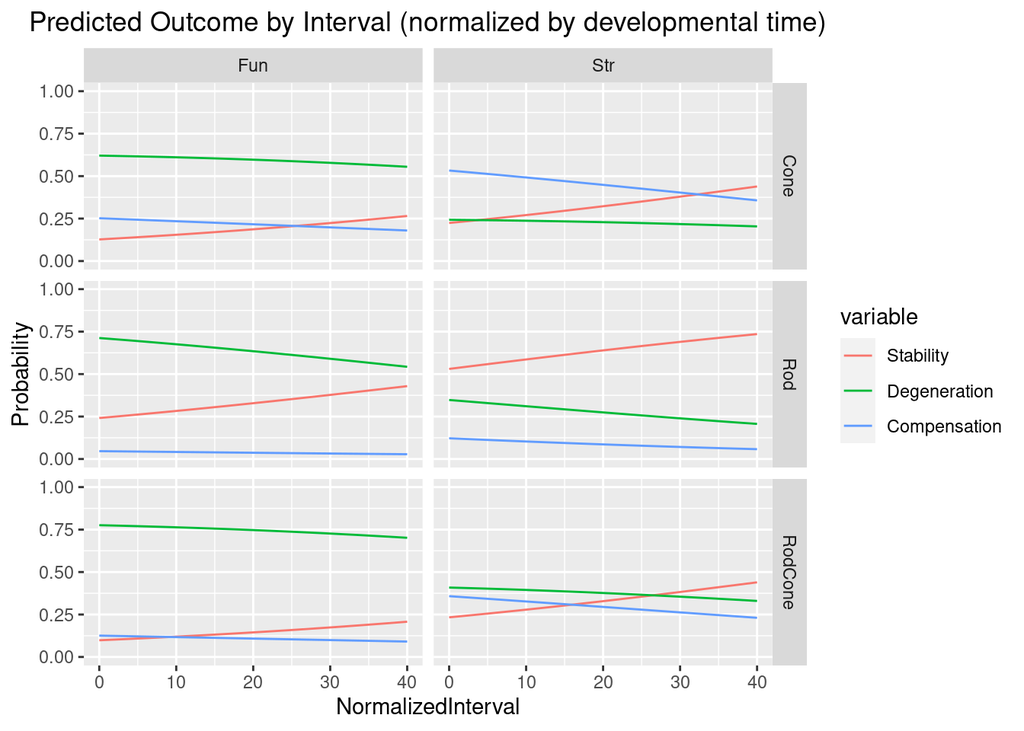

```r
# Plot predicted probabilities across NormalizedInterval values for each level of Outcome facetted by RodCone and Method of investigation
ggplot(lpp, aes(x = NormalizedInterval, y = Probability, colour = variable)) +
  geom_line() + facet_grid(RodCone ~ Method, scales = "free_x") +
  ggtitle("Predicted Outcome by Interval (normalized by developmental time)") +
  theme(plot.title = element_text(hjust = 0.5)) + ylim(0,1)
```

### Entire PR

Predict probability by total amount of photoreceptors affected, assuming the following distribution: Cones: between 0 and 3%, Rods: between 0 and 97%

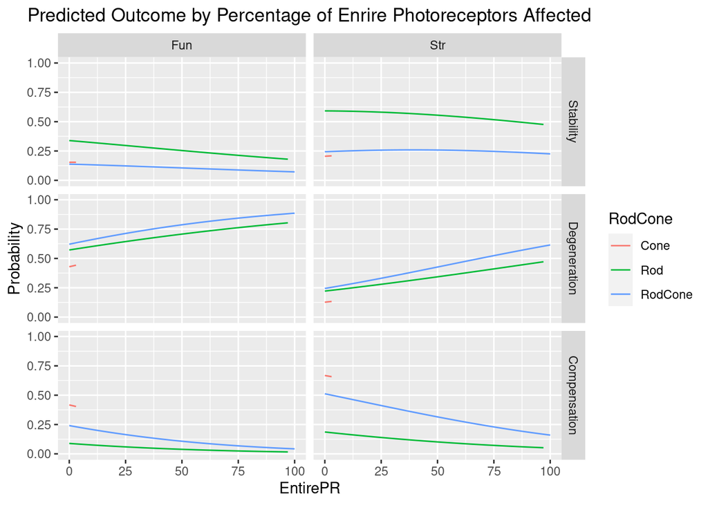

```r
percCone = seq(0, 3, by=0.5)
percRod = seq(0, 97, by=0.5)
percRodCone = seq(0, 100, by=0.5)

dConePR = data.frame(Method = rep(levels(df$Method), each = length(percCone)),
                   RodCone = rep("Cone", each = length(percCone)),
                   NormalizedAge =  mean(df$NormalizedAge),
                   NormalizedInterval = mean(df$NormalizedInterval),
                   EntirePR = percCone,
                   SpecificPR = mean(df$SpecificPR))

dRodPR = data.frame(Method = rep(levels(df$Method), each = length(percRod)),
                   RodCone = rep("Rod", each = length(percRod)),
                   NormalizedAge =  mean(df$NormalizedAge),
                   NormalizedInterval = mean(df$NormalizedInterval),
                   EntirePR = percRod,
                   SpecificPR = mean(df$SpecificPR))

dRodConePR = data.frame(Method = rep(levels(df$Method), each = length(percRodCone)),
                   RodCone = rep("RodCone", each = length(percRodCone)),
                   NormalizedAge =  mean(df$NormalizedAge),
                   NormalizedInterval = mean(df$NormalizedInterval),
                   EntirePR = percRodCone,
                   SpecificPR = mean(df$SpecificPR))

dEntirePR = rbind(dConePR, dRodPR, dRodConePR)

#dEntirePR <- data.frame(Method = rep(levels(df$Method), each = length(unique(df$EntirePR))*length(levels(df$RodCone))),
#                   RodCone = rep(levels(df$RodCone), each = length(unique(df$EntirePR))),
#                   NormalizedAge =  mean(df$NormalizedAge),
#                   NormalizedInterval = mean(df$NormalizedInterval),
#                   EntirePR = rep(sort(unique(df$EntirePR)), length(levels(df$RodCone))),
#                   SpecificPR = mean(df$SpecificPR))

# Store the predicted probabilities for each value of RodCone and D50 and append as last 3 columns to dataframe (columns 9, 10, 11)
pp <- cbind(dEntirePR, predict(mdl, newdata = dEntirePR, type = "probs", se = TRUE))

# calculate the mean probabilities within each level of RodCone
#by(pp[, (ncol(pp)-2):ncol(pp)], pp$RodCone, colMeans)

# Collapse the data frame by outcome
lpp <- melt(pp, id.vars = c("RodCone", "EntirePR", "Method"), measure.vars = levels(df$Outcome), value.name = "Probability")

# Plot predicted probabilities across EntirePR values for each level of RodCone facetted by Outcome and Method
ggplot(lpp, aes(x = EntirePR, y = Probability, colour = RodCone)) +
  geom_line() + facet_grid(variable ~ Method, scales = "free")  +
  ggtitle("Predicted Outcome by Percentage of Enrire Photoreceptors Affected") +
  theme(plot.title = element_text(hjust = 0.5))  + ylim(0,1)
```

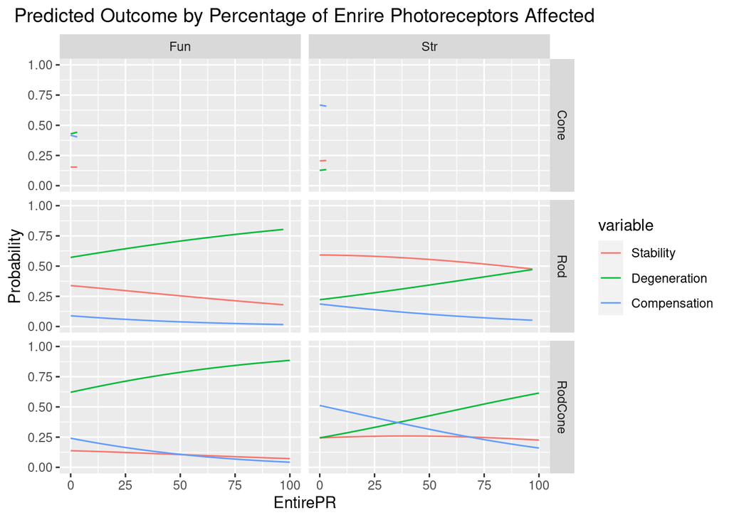

```r
# Plot predicted probabilities across EntirePR values for each level of Outcome facetted by RodCone and Method
ggplot(lpp, aes(x = EntirePR, y = Probability, colour = variable)) +
  geom_line() + facet_grid(RodCone ~ Method, scales = "free")  +
  ggtitle("Predicted Outcome by Percentage of Enrire Photoreceptors Affected") +
  theme(plot.title = element_text(hjust = 0.5))  + ylim(0,1)
```

### Specific PR

Predict probability of each outcome by the amount of scpecific photoreceptors affected.

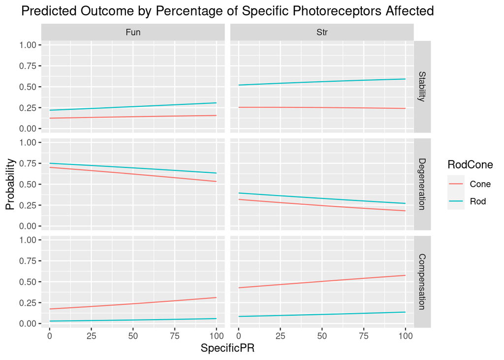

```r
percRodCone = seq(0, 100, by=0.5)
typePR = c("Rod", "Cone")

dSpecificPR <- data.frame(Method = rep(levels(df$Method), each = length(percRodCone)*length(typePR)),
                   RodCone = rep(typePR, each = length(percRodCone)),
                   NormalizedAge =  mean(df$NormalizedAge),
                   NormalizedInterval = mean(df$NormalizedInterval),
                   EntirePR =  mean(df$EntirePR),
                   SpecificPR = rep(percRodCone, length(levels(df$Method))*length(typePR)))

# Store the predicted probabilities for each value of RodCone and D50 and append as last 3 columns to dataframe (columns 9, 10, 11)
pp <- cbind(dSpecificPR, predict(mdl, newdata = dSpecificPR, type = "probs", se = TRUE))

# calculate the mean probabilities within each level of RodCone
#by(pp[, (ncol(pp)-2):ncol(pp)], pp$RodCone, colMeans)

# Collapse the data frame by outcome
lpp <- melt(pp, id.vars = c("RodCone", "SpecificPR", "Method"), measure.vars = levels(df$Outcome), value.name = "Probability")

# Plot predicted probabilities across SpecificPR values for each level of RodCone facetted by Outcome and Method
ggplot(lpp, aes(x = SpecificPR, y = Probability, colour = RodCone)) +
  geom_line() + facet_grid(variable ~ Method, scales = "free")  +
  ggtitle("Predicted Outcome by Percentage of Specific Photoreceptors Affected") +
  theme(plot.title = element_text(hjust = 0.5))  + ylim(0,1)
```

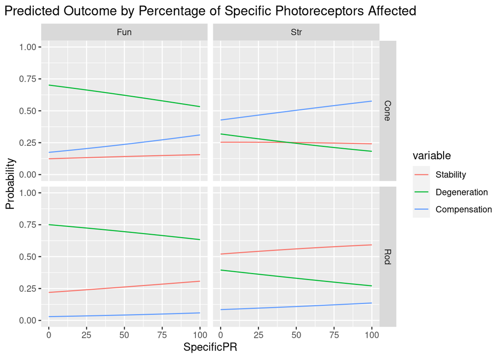

```r
# Plot predicted probabilities across SpecificPR values for each level of Outcome facetted by RodCone and Method
ggplot(lpp, aes(x = SpecificPR, y = Probability, colour = variable)) +
  geom_line() + facet_grid(RodCone ~ Method, scales = "free")  +
  ggtitle("Predicted Outcome by Percentage of Specific Photoreceptors Affected") +
  theme(plot.title = element_text(hjust = 0.5))  + ylim(0,1)
```

# Model 3: RodCone

## Multinomial Regression Model

Multinomial regression (nnet:multinom), it is a log-linear model for which the resulting coefficients reflect the ratio of probability Removed the Manipulation parameter because not significant in the model and the Method of investigtion to simplify prediction

```r
df$Outcome<-relevel(df$Outcome, ref="Stability")

mdl <- multinom(Outcome ~ RodCone + NormalizedAge + NormalizedInterval + EntirePR + SpecificPR, data = df)
summary(mdl)
```

```
## Call:
## multinom(formula = Outcome ~ RodCone + NormalizedAge + NormalizedInterval +
##     EntirePR + SpecificPR, data = df)
##
## Coefficients:
##              (Intercept) RodConeCone RodConeRodCone NormalizedAge
## Degeneration   0.6068506    0.357160       0.481198    -0.4416373
## Compensation  -1.1963330    2.358453       1.930339    -0.4656464
##              NormalizedInterval     EntirePR   SpecificPR
## Degeneration        -0.01362851  0.008435399 -0.007130533
## Compensation        -0.02737384 -0.010600621  0.003910145
##
## Std. Errors:
##              (Intercept) RodConeCone RodConeRodCone NormalizedAge
## Degeneration   0.2166044   0.5920231      0.2810616     0.2566717
## Compensation   0.3437991   0.5955388      0.4000903     0.3060404
##              NormalizedInterval    EntirePR  SpecificPR
## Degeneration         0.01375031 0.006390043 0.006681305
## Compensation         0.02279091 0.007039747 0.007249175
##
## Residual Deviance: 848.3773
## AIC: 876.3773
```

## ANOVA

Parameters significant for the model are: Rod/Cone affected and Entire PR affected.

```r
Anova(mdl)
```

|  | LR Chisq | Df | Pr(>Chisq) |
| --- | --- | --- | --- |
| RodCone | 33.296770 | 4 | 1.038492e-06 |
| NormalizedAge | 3.613501 | 2 | 1.641868e-01 |
| NormalizedInterval | 1.777635 | 2 | 4.111416e-01 |
| EntirePR | 8.387492 | 2 | 1.508965e-02 |
| SpecificPR | 2.831310 | 2 | 2.427665e-01 |

## Wald-test (2-tailed z test)

```r
z <- summary(mdl)$coefficients/summary(mdl)$standard.errors
p <- (1 - pnorm(abs(z), 0, 1)) * 2
p
```

```
##              (Intercept)  RodConeCone RodConeRodCone NormalizedAge
## Degeneration 0.005084128 5.463176e-01   8.688322e-02     0.0853178
## Compensation 0.000501893 7.488683e-05   1.401725e-06     0.1281295
##              NormalizedInterval  EntirePR SpecificPR
## Degeneration          0.3216162 0.1868067  0.2858650
## Compensation          0.2297178 0.1321123  0.5896166
```

## Relative risk

```r
writeLines("Ratio of the probability of choosing one outcome category over the reference category.\nOften referred as relative risk (and sometimes referred to as odds).\nCalculated by extracting the coefficients from the model and exponentiating\n")
```

```
## Ratio of the probability of choosing one outcome category over the reference category.
## Often referred as relative risk (and sometimes referred to as odds).
## Calculated by extracting the coefficients from the model and exponentiating
```

```r
exp(coef(mdl))
```

```
##              (Intercept) RodConeCone RodConeRodCone NormalizedAge
## Degeneration   1.8346443    1.429265       1.618012     0.6429828
## Compensation   0.3023007   10.574582       6.891849     0.6277292
##              NormalizedInterval  EntirePR SpecificPR
## Degeneration          0.9864639 1.0084711  0.9928948
## Compensation          0.9729974 0.9894554  1.0039178
```

```r
#writeLines("\nPredicted probabilities for the source data (head of table)")
#head(fitted(mdl))
```

## Predicted probabilities

### Categorical Parameters

```r
dsim <- data.frame(RodCone = levels(df$RodCone),
                   NormalizedAge = mean(df$NormalizedAge),
                   NormalizedInterval = mean(df$NormalizedInterval),
                   EntirePR = mean(df$EntirePR),
                   SpecificPR = mean(df$SpecificPR))
pred <- predict(mdl, newdata = dsim, "probs")

dfPred <- as.data.frame(pred)
row.names(dfPred) <- NULL
dfPred <- roundDf(dfPred, digits=2)
Photoreceptor <- c(levels(df$RodCone))
dfPred <- cbind(Photoreceptor, dfPred)
z <- ztable(dfPred) %>%
  print(caption = "Predicted outcome probability by photoreceptor type")
```

Predicted outcome probability by photoreceptor type

|  | Photoreceptor | Stability | Degeneration | Compensation |
| --- | --- | --- | --- | --- |
| 1 | Rod | 0.37 | 0.56 | 0.07 |
| 2 | Cone | 0.20 | 0.43 | 0.38 |
| 3 | RodCone | 0.21 | 0.52 | 0.27 |

### Age

Predicts outcome based on age (normalized by developmental time) at which the pathology starts

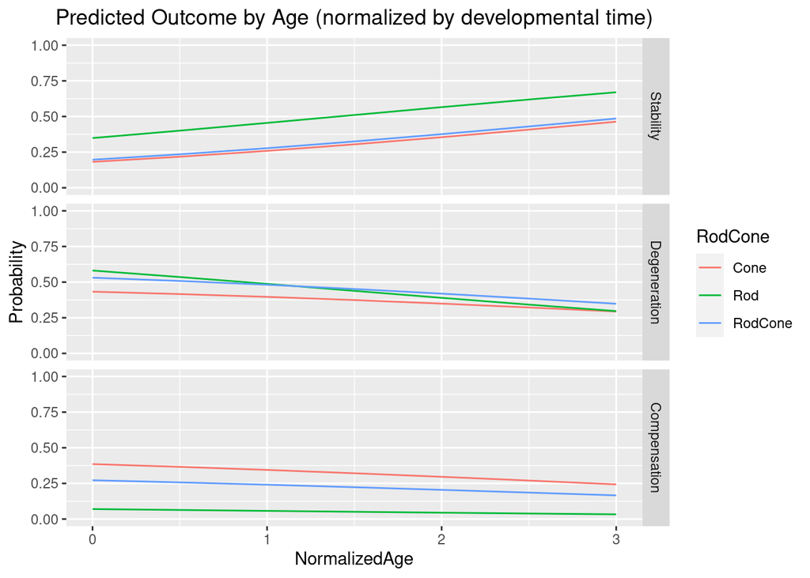

```r
# Distribution of data (cone = 0 to 1.428, rod = 0 to 1.428, rod/cone 0 to 2.666)
percCone = seq(0, 3.0, by=0.5)
percRod = seq(0, 3.0, by=0.5)
percRodCone = seq(0, 3.0, by=0.5)

dConePR <-data.frame(RodCone = rep("Cone", each = length(percCone)),
                   NormalizedAge =  percCone,
                   NormalizedInterval = mean(df$NormalizedInterval),
                   EntirePR =  mean(df$EntirePR),
                   SpecificPR = mean(df$SpecificPR))

dRodPR <-data.frame(RodCone = rep("Rod", each = length(percRod)),
                   NormalizedAge =  percRod,
                   NormalizedInterval = mean(df$NormalizedInterval),
                   EntirePR = mean(df$EntirePR),
                   SpecificPR = mean(df$SpecificPR))

dRodConePR <- data.frame(RodCone = rep("RodCone", each = length(percRodCone)),
                   NormalizedAge =  percRodCone,
                   NormalizedInterval = mean(df$NormalizedInterval),
                   EntirePR = mean(df$EntirePR),
                   SpecificPR = mean(df$SpecificPR))

dNormalizedAge <- rbind(dConePR, dRodPR, dRodConePR)
# Store the predicted probabilities for each value of RodCone and NormalizedAge and append as last 3 columns to data frame (last three columns)
pred <- predict(mdl, newdata = dNormalizedAge, type = "probs", se = TRUE)
pp <- cbind(dNormalizedAge, pred)

# calculate the mean probabilities within each level of RodCone
#by(pp[, (ncol(pp)-2):ncol(pp)], pp$RodCone, colMeans)

# Collapse the data frame by outcome
lpp <- melt(pp, id.vars = c("RodCone", "NormalizedAge"), measure.vars = levels(df$Outcome), value.name = "Probability")

# Plot predicted probabilities across NormalizedAge values for each level of RodCone facetted by Outcome
ggplot(lpp, aes(x = NormalizedAge, y = Probability, colour = RodCone)) +
  geom_line() + facet_grid(variable ~ ., scales = "free_x") +
  ggtitle("Predicted Outcome by Age (normalized by developmental time)") +
  theme(plot.title = element_text(hjust = 0.5)) + ylim(0,1)
```

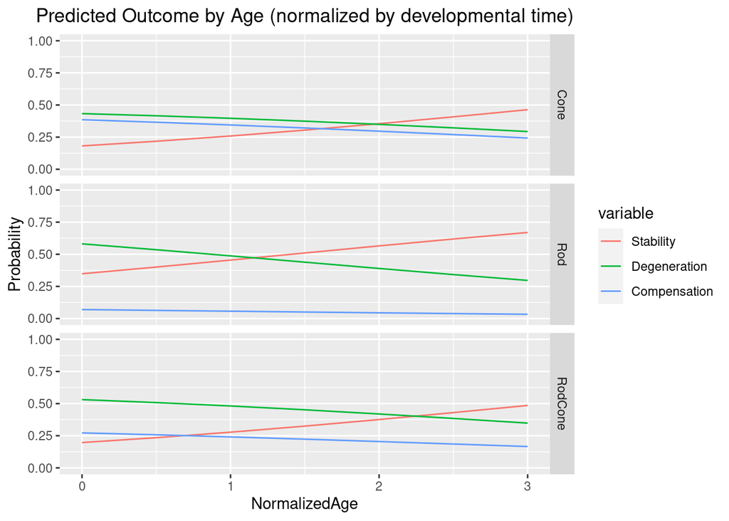

```r
# Collapse the data frame by RodCone
lpp <- melt(pp, id.vars = c("RodCone", "NormalizedAge"), measure.vars = levels(df$Outcome), value.name = "Probability")

# Plot predicted probabilities across NormalizedAge values for each level of Outcome facetted by RodCone
ggplot(lpp, aes(x = NormalizedAge, y = Probability, colour = variable)) +
  geom_line() + facet_grid(RodCone ~ ., scales = "free_x") +
  ggtitle("Predicted Outcome by Age (normalized by developmental time)") +
  theme(plot.title = element_text(hjust = 0.5)) + ylim(0,1)
```

### Interval

Predicts outcome based on time interval (normalized by developmental time) during which the pathology develops

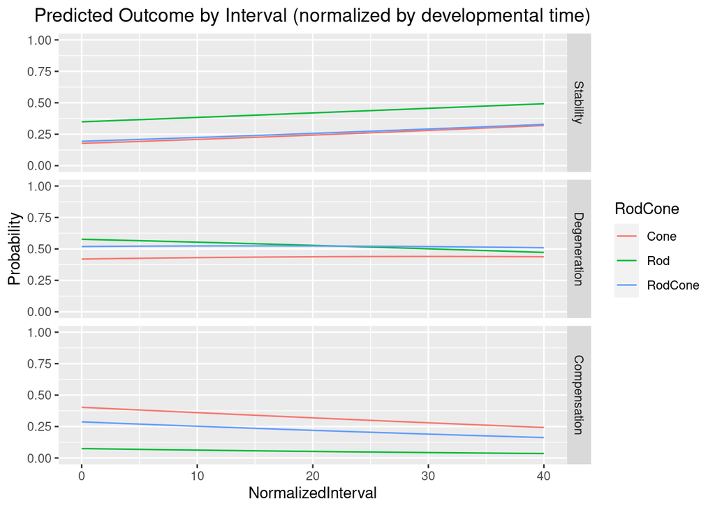

```r
# Distribution of data (cone = 0 to 24.28, rod = 0 to 40, rod/cone 0 to 34.28)
percCone = seq(0, 40, by=2)
percRod = seq(0, 40, by=2)
percRodCone = seq(0, 40, by=2)

dConePR <-data.frame(RodCone = rep("Cone", each = length(percCone)),
                   NormalizedAge =  mean(df$NormalizedAge),
                   NormalizedInterval = percCone,
                   EntirePR =  mean(df$EntirePR),
                   SpecificPR = mean(df$SpecificPR))

dRodPR <-data.frame(RodCone = rep("Rod", each = length(percRod)),
                   NormalizedAge =  mean(df$NormalizedAge),
                   NormalizedInterval = percRod,
                   EntirePR = mean(df$EntirePR),
                   SpecificPR = mean(df$SpecificPR))

dRodConePR <- data.frame(RodCone = rep("RodCone", each = length(percRodCone)),
                   NormalizedAge =  mean(df$NormalizedAge),
                   NormalizedInterval =percRodCone,
                   EntirePR = mean(df$EntirePR),
                   SpecificPR = mean(df$SpecificPR))

dNormalizedInterval <- rbind(dConePR, dRodPR, dRodConePR)
# Store the predicted probabilities for each value of RodCone and D50 and append as last 3 columns to dataframe (columns 9, 10, 11)
pp <- cbind(dNormalizedInterval, predict(mdl, newdata = dNormalizedInterval, type = "probs", se = TRUE))

# calculate the mean probabilities within each level of RodCone
#by(pp[, (ncol(pp)-2):ncol(pp)], pp$RodCone, colMeans)

# Collapse the data frame by outcome
lpp <- melt(pp, id.vars = c("RodCone", "NormalizedInterval"), measure.vars = levels(df$Outcome), value.name = "Probability")

# Plot predicted probabilities across NormalizedInterval values for each level of RodCone facetted by Outcome
ggplot(lpp, aes(x = NormalizedInterval, y = Probability, colour = RodCone)) +
  geom_line() + facet_grid(variable ~ ., scales = "free_x") +
  ggtitle("Predicted Outcome by Interval (normalized by developmental time)") +
  theme(plot.title = element_text(hjust = 0.5)) + ylim(0,1)
```

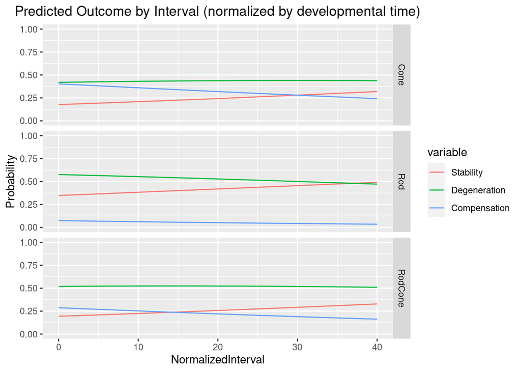

```r
# Plot predicted probabilities across NormalizedInterval values for each level of Oucome facetted by RodCone
ggplot(lpp, aes(x = NormalizedInterval, y = Probability, colour = variable)) +
  geom_line() + facet_grid(RodCone ~ ., scales = "free_x") +
  ggtitle("Predicted Outcome by Interval (normalized by developmental time)") +
  theme(plot.title = element_text(hjust = 0.5)) + ylim(0,1)
```

### Entire PR

Predict probability by total amount of photoreceptors affected, assuming the following distribution: Cones: between 0 and 3%, Rods: between 0 and 97%

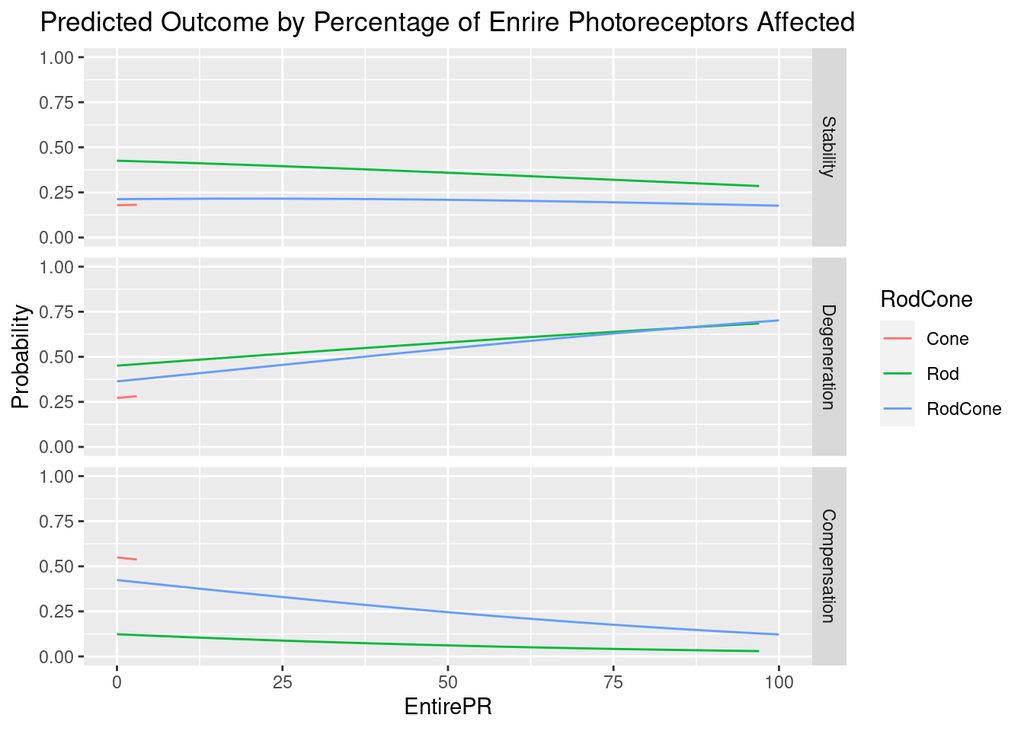

```r
percCone = seq(0, 3, by=0.5)
percRod = seq(0, 97, by=0.5)
percRodCone = seq(0, 100, by=0.5)

dConePR <-data.frame(RodCone = rep("Cone", each = length(percCone)),
                   NormalizedAge =  mean(df$NormalizedAge),
                   NormalizedInterval = mean(df$NormalizedInterval),
                   EntirePR = percCone,
                   SpecificPR = mean(df$SpecificPR))

dRodPR <-data.frame(RodCone = rep("Rod", each = length(percRod)),
                   NormalizedAge =  mean(df$NormalizedAge),
                   NormalizedInterval = mean(df$NormalizedInterval),
                   EntirePR = percRod,
                   SpecificPR = mean(df$SpecificPR))

dRodConePR <- data.frame(RodCone = rep("RodCone", each = length(percRodCone)),
                   NormalizedAge =  mean(df$NormalizedAge),
                   NormalizedInterval = mean(df$NormalizedInterval),
                   EntirePR = percRodCone,
                   SpecificPR = mean(df$SpecificPR))

dEntirePR <- rbind(dConePR, dRodPR, dRodConePR)

# Store the predicted probabilities for each value of RodCone and D50 and append as last 3 columns to dataframe (columns 9, 10, 11)
pp <- cbind(dEntirePR, predict(mdl, newdata = dEntirePR, type = "probs", se = TRUE))

# calculate the mean probabilities within each level of RodCone
#by(pp[, (ncol(pp)-2):ncol(pp)], pp$RodCone, colMeans)

# Collapse the data frame by outcome
lpp <- melt(pp, id.vars = c("RodCone", "EntirePR"), measure.vars = levels(df$Outcome), value.name = "Probability")

# Plot predicted probabilities across EntirePR values for each level of RodCone facetted by Outcome
ggplot(lpp, aes(x = EntirePR, y = Probability, colour = RodCone)) +
  geom_line() + facet_grid(variable ~ ., scales = "free")  +
  ggtitle("Predicted Outcome by Percentage of Enrire Photoreceptors Affected") +
  theme(plot.title = element_text(hjust = 0.5))  + ylim(0,1)
```

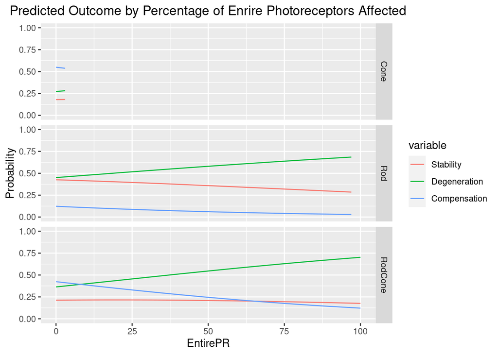

```r
# Plot predicted probabilities across EntirePR values for each level of Oucome facetted by RodCone
ggplot(lpp, aes(x = EntirePR, y = Probability, colour = variable)) +
  geom_line() + facet_grid(RodCone ~ ., scales = "free")  +
  ggtitle("Predicted Outcome by Percentage of Enrire Photoreceptors Affected") +
  theme(plot.title = element_text(hjust = 0.5))  + ylim(0,1)
```

### Specific PR

Predict probability of each outcome by the amount of scpecific photoreceptors affected.

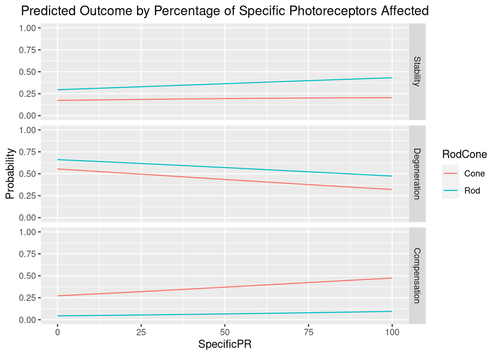

```r
percRodCone = seq(0, 100, by=0.5)
typePR = c("Rod", "Cone")

dSpecificPR <- data.frame(RodCone = rep(typePR, each = length(percRodCone)),
                   NormalizedAge =  mean(df$NormalizedAge),
                   NormalizedInterval = mean(df$NormalizedInterval),
                   EntirePR =  mean(df$EntirePR),
                   SpecificPR = rep(percRodCone, length(typePR)))

# Store the predicted probabilities for each value of RodCone and D50 and append as last 3 columns to dataframe (columns 9, 10, 11)
pp <- cbind(dSpecificPR, predict(mdl, newdata = dSpecificPR, type = "probs", se = TRUE))

# calculate the mean probabilities within each level of RodCone
#by(pp[, (ncol(pp)-2):ncol(pp)], pp$RodCone, colMeans)

# Collapse the data frame by outcome
lpp <- melt(pp, id.vars = c("RodCone", "SpecificPR"), measure.vars = levels(df$Outcome), value.name = "Probability")

# Plot predicted probabilities across SpecificPR values for each level of RodCone facetted by Outcome
ggplot(lpp, aes(x = SpecificPR, y = Probability, colour = RodCone)) +
  geom_line() + facet_grid(variable ~ ., scales = "free")  +
  ggtitle("Predicted Outcome by Percentage of Specific Photoreceptors Affected") +
  theme(plot.title = element_text(hjust = 0.5))  + ylim(0,1)
```

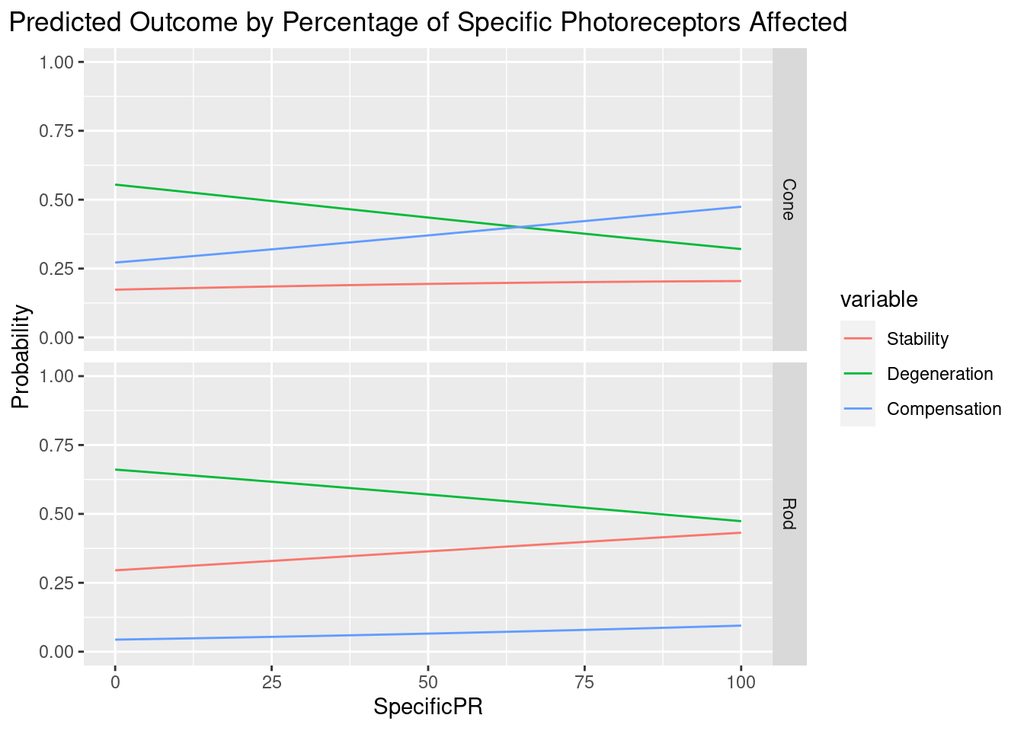

```r
# Plot predicted probabilities across SpecificPR values for each level of Oucome facetted by RodCone
ggplot(lpp, aes(x = SpecificPR, y = Probability, colour = variable)) +
  geom_line() + facet_grid(RodCone ~ ., scales = "free")  +
  ggtitle("Predicted Outcome by Percentage of Specific Photoreceptors Affected") +
  theme(plot.title = element_text(hjust = 0.5))  + ylim(0,1)
```

# Model 4: Manipulation

## Multinomial Regression Model

```r
df$Outcome<-relevel(df$Outcome, ref="Stability")

mdl <- multinom(Outcome ~ Manipulation, data = df)
summary(mdl)
```

```
## Call:
## multinom(formula = Outcome ~ Manipulation, data = df)
##
## Coefficients:
##              (Intercept) ManipulationSignaling ManipulationTrafficking
## Degeneration   0.6531455            -0.1721572             -0.08603661
## Compensation  -0.5306317             0.5306523             -1.31522009
##              ManipulationOthers
## Degeneration         0.24764434
## Compensation         0.04513867
##
## Std. Errors:
##              (Intercept) ManipulationSignaling ManipulationTrafficking
## Degeneration   0.1726613             0.2782190               0.2665578
## Compensation   0.2300899             0.3343128               0.4959113
##              ManipulationOthers
## Degeneration          0.3714638
## Compensation          0.5048400
##
## Residual Deviance: 899.9314
## AIC: 915.9314
```

## ANOVA

```r
Anova(mdl)
```

|  | LR Chisq | Df | Pr(>Chisq) |
| --- | --- | --- | --- |
| Manipulation | 23.72861 | 6 | 0.0005858098 |

## Wald-test (2-tailed z test)

```r
z <- summary(mdl)$coefficients/summary(mdl)$standard.errors
p <- (1 - pnorm(abs(z), 0, 1)) * 2
p
```

```
##               (Intercept) ManipulationSignaling ManipulationTrafficking
## Degeneration 0.0001550659             0.5360593             0.746870142
## Compensation 0.0210998555             0.1124463             0.007998629
##              ManipulationOthers
## Degeneration          0.5049820
## Compensation          0.9287546
```

## Relative risk

```r
writeLines("Ratio of the probability of choosing one outcome category over the reference category.\nOften referred as relative risk (and sometimes referred to as odds).\nCalculated by extracting the coefficients from the model and exponentiating\n")
```

```
## Ratio of the probability of choosing one outcome category over the reference category.
## Often referred as relative risk (and sometimes referred to as odds).
## Calculated by extracting the coefficients from the model and exponentiating
```

```r
exp(coef(mdl))
```

```
##              (Intercept) ManipulationSignaling ManipulationTrafficking
## Degeneration   1.9215756             0.8418468               0.9175606
## Compensation   0.5882333             1.7000409               0.2684152
##              ManipulationOthers
## Degeneration           1.281004
## Compensation           1.046173
```

```r
#writeLines("\nPredicted probabilities for the source data (head of table)")
#head(fitted(mdl))
```

## Predicted probabilities

### Categorical Parameters

```r
dsim <- data.frame(Manipulation = levels(df$Manipulation))
pred <- predict(mdl, newdata = dsim, "probs")

dfPred <- as.data.frame(pred)
row.names(dfPred) <- NULL
dfPred <- roundDf(dfPred, digits=2)
Manipulation <- c(levels(df$Manipulation))
dfPred <- cbind(Manipulation, dfPred)
z <- ztable(dfPred) %>%
  print(caption = "Predicted utcome probability by manipulation")
```

Predicted utcome probability by manipulation

|  | Manipulation | Stability | Degeneration | Compensation |
| --- | --- | --- | --- | --- |
| 1 | Phototransduction | 0.28 | 0.55 | 0.17 |
| 2 | Signaling | 0.28 | 0.45 | 0.28 |
| 3 | Trafficking | 0.34 | 0.60 | 0.05 |
| 4 | Others | 0.25 | 0.60 | 0.15 |